# Reproducible Research Project

##### 2. Make a histogram

If you do not understand the difference between a histogram and a barplot, research the difference between them. Make a histogram of the total number of steps taken each day

**a. histogram plot of total steps in each day:**

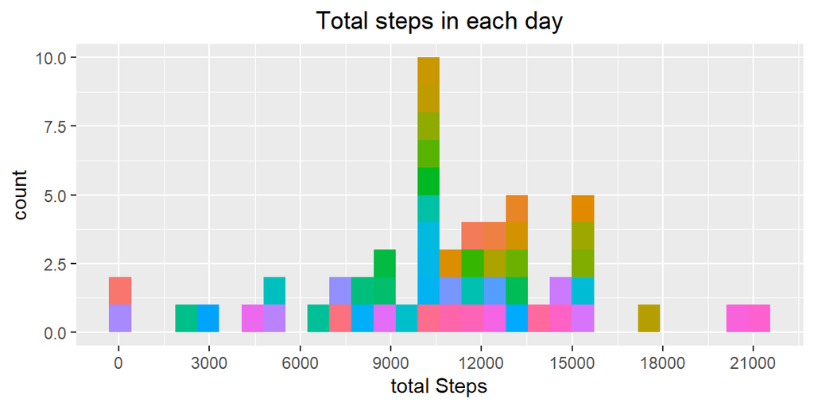

```r
TotalSteps %>%  ggplot2::ggplot(aes(totalSt, fill = as.factor(date))) +
                        geom_histogram()+
                        scale_x_continuous(breaks = seq(min(TotalSteps$totalSt,na.rm = TRUE)-41,
                                                        max(TotalSteps$totalSt,na.rm = TRUE), by = 3000))+
                        labs(fill = "date")+
                        labs(title = "Total steps in each day",
                             x = "total Steps",
                             ) +
                         theme(plot.title = element_text(hjust = 0.5),
                               legend.position = "none"
                               )
```

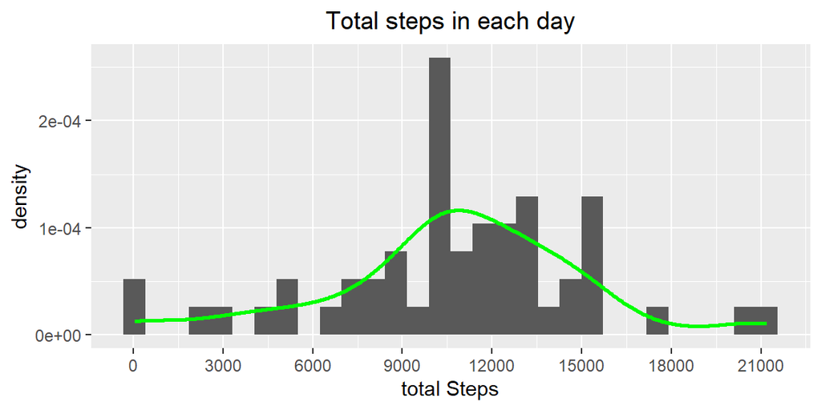

```r
# added density line to the histogram plot (it isnt required to be applied for the assignement)
ggplot2::ggplot(TotalSteps, aes(x = totalSt, y = after_stat(density))) +
        geom_histogram()+
        scale_x_continuous(breaks = seq(min(TotalSteps$totalSt, na.rm = TRUE)-41,
                                        max(TotalSteps$totalSt, na.rm = TRUE),
                                        by = 3000))+
        geom_density(color = "green", linewidth = 1)+
        labs(
           title = "Total steps in each day",
           x = "total Steps",
           ) +
        theme(plot.title = element_text(hjust = 0.5)
             )
```

**b. bar plot: for practice I generated bar plot as well.**

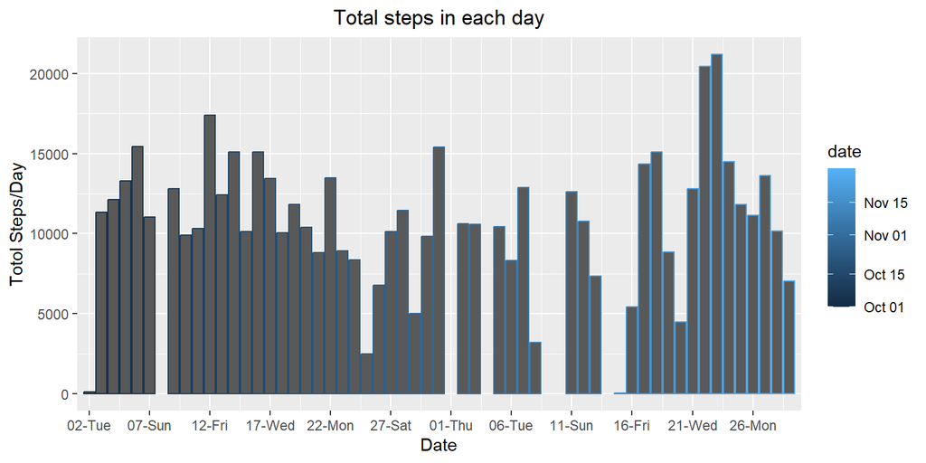

```r
TotalSteps %>% ggplot(aes(date, totalSt, colour = date)) +
              geom_bar(stat="identity")+
              scale_x_date(date_labels = "%d-%a",
                           date_breaks = "5 day",
                           limits = c(min(Activity1$date), max(Activity1$date)),
                           expand = c(0, 0))+
              labs(
                 title = "Total steps in each day",
                 x = "Date",
                 y = "Totol Steps/Day") +
              theme(plot.title = element_text(hjust = 0.5)
                   )
```

##### Q3. Calculate and report the mean and median of the total number of steps taken per day

```r
ActMnMdn <- TotalSteps %>% select(date, totalSt)%>%
  summarise(mean = mean(totalSt, na.rm = TRUE),
            median = median(totalSt, na.rm = TRUE))

# Note: dplyr verbs returns tibble instead of data frame
ActMnMdn
```

```
## # A tibble: 1 × 2
##     mean median
##    <dbl>  <int>
## 1 10766.  10765
```

### Question 3.

What is the average daily activity pattern?

```r
# for time series plot, the inteval formate should be numeric. it is now factor.
# ActAveraged$interval <- as.numeric(ActAveraged$interval)
ActAveraged <- Activity1 %>% group_by(interval) %>%
  summarise(meanSt = mean(steps, na.rm = TRUE))

str(ActAveraged)
```

```
## tibble [288 × 2] (S3: tbl_df/tbl/data.frame)
##  $ interval: int [1:288] 0 5 10 15 20 25 30 35 40 45 ...
##  $ meanSt  : num [1:288] 1.717 0.3396 0.1321 0.1509 0.0755 ...
```

```r
# the maximum number of steps?

# ActAveraged[which.max(ActAveraged$meanSt), ]
ActAveraged %>% filter(meanSt == max(meanSt))
```

```
## # A tibble: 1 × 2
##   interval meanSt
##      <int>  <dbl>
## 1      835   206.
```

### Question 4.

**Imputing missing values**

Note that there are a number of days/intervals where there are missing values (coded as NA). The presence of missing days may introduce bias into some calculations or summaries of the data.

##### 1. Calculate and report the total number of missing values in the dataset (i.e. the total number of rows with NAs)

```r
#checking for number of Nas in each column

colSums(is.na(Activity)) #to achieve the result apply()and sapply() can also be applied
```

```
##    steps     date interval
##     2304        0        0
```

##### 2. Devise a strategy for filling in all of the missing values in the dataset. The strategy does not need to be sophisticated.

For example, you could use the mean/median for that day, or the mean for that 5-minute interval, etc.

```r
# filter the dataset to locate where the NAs are existing
ActMissing <- Activity1[which(is.na(Activity1$steps)),]

unique(ActMissing$date) # what days/dates, Steps variable contain missing values
```

```
## [1] "2012-10-01" "2012-10-08" "2012-11-01" "2012-11-04" "2012-11-09"
## [6] "2012-11-10" "2012-11-14" "2012-11-30"
```

**a. filling the NAs with mean for that day**

```r
ActFillingDT <- Activity1 %>%
                select(steps, date, interval) %>%
                group_by(date) %>%
                mutate(st = ifelse(is.na(steps),
                                   ifelse(all(is.na(steps)),
                                          # if only one group has entirely NAs,
                                          mean(Activity1$steps, na.rm = TRUE),
# then get mean of variable "Steps" across the entire dataset
                                   mean(steps, na.rm = TRUE)),
#then get mean of that group If not all values are missing (just some are NAs in a group) .
                                   steps)) # otherwise if a row in a group has valid value then keep it.
ActFillingDT
```

```
## # A tibble: 17,568 × 4
## # Groups:   date [61]
##    steps date       interval    st
##    <int> <date>        <int> <dbl>
##  1    NA 2012-10-01        0  37.4
##  2    NA 2012-10-01        5  37.4
##  3    NA 2012-10-01       10  37.4
##  4    NA 2012-10-01       15  37.4
##  5    NA 2012-10-01       20  37.4
##  6    NA 2012-10-01       25  37.4
##  7    NA 2012-10-01       30  37.4
##  8    NA 2012-10-01       35  37.4
##  9    NA 2012-10-01       40  37.4
## 10    NA 2012-10-01       45  37.4
## # ℹ 17,558 more rows
```

```r
# check if the filling is done accurately in specific dates
ActFillingDT[which(ActFillingDT$date == "2012-10-01"), ]
ActFillingDT[which(ActFillingDT$date == "2012-10-19"), ]
ActFillingDT[which(ActFillingDT$date == "2012-10-08"), ]
```

[output not shown]

**b. filling the NAs with mean for that 5-minute interval across all days**

```r
ActfillingInt <- Activity1 %>% select(interval, date, steps) %>%
                               group_by(interval) %>%
                               mutate(steps = ifelse(is.na(steps),
                                                      ifelse(all(is.na(steps)),
# if only one group has entirely NAs,
                                                             mean(Activity3$steps, na.rm = TRUE),
# then get mean of variable "Steps" across the entire dataset
                                                       mean(steps, na.rm = TRUE)),
# If not all are missing (juss some are NAs in a group) then get mean of that group.
                                                       steps))
ActfillingInt
```

```
## # A tibble: 17,568 × 3
## # Groups:   interval [288]
##    interval date        steps
##       <int> <date>      <dbl>
##  1        0 2012-10-01 1.72
##  2        5 2012-10-01 0.340
##  3       10 2012-10-01 0.132
##  4       15 2012-10-01 0.151
##  5       20 2012-10-01 0.0755
##  6       25 2012-10-01 2.09
##  7       30 2012-10-01 0.528
##  8       35 2012-10-01 0.868
##  9       40 2012-10-01 0
## 10       45 2012-10-01 1.47
## # ℹ 17,558 more rows
```

```r
# check if the filling is done accurately in specific dates
ActfillingInt[ActfillingInt$date == "2012-10-01", ]
ActfillingInt[ActfillingInt$date == "2012-10-19", ]
ActfillingInt[ActfillingInt$date == "2012-10-08", ]
```

[output not shown]